# Trial

Niteshyadav sanna

02-25-2024

```r
knitr::opts_chunk$set(echo = TRUE, comment = NA)
```

*QUESTION* Universal bank is a young bank growing rapidly in terms of overall customer acquisition. The majority of these customers are liability customers (depositors) with varying sizes of relationship with the bank. The customer base of asset customers (borrowers) is quite small, and the bank is interested in expanding this base rapidly in more loan business. In particular, it wants to explore ways of converting its liability customers to personal loan customers.

A campaign that the bank ran last year for liability customers showed a healthy conversion rate of over 9% success. This has encouraged the retail marketing department to devise smarter campaigns with better target marketing. The goal is to use k-NN to predict whether a new customer will accept a loan offer. This will serve as the basis for the design of a new campaign.

The file UniversalBank.csv contains data on 5000 customers. The data include customer demographic information (age, income, etc.), the customer’s relationship with the bank (mortgage, securities account, etc.), and the customer response to the last personal loan campaign (Personal Loan). Among these 5000 customers, only 480 (= 9.6%) accepted the personal loan that was offered to them in the earlier campaign.

Partition the data into training (60%) and validation (40%) sets.

Consider the following customer:

1. Age = 40, Experience = 10, Income = 84, Family = 2, CCAvg = 2, Education_1 = 0, Education_2 = 1, Education_3 = 0, Mortgage = 0, Securities Account = 0, CD Account = 0, Online = 1, and Credit Card = 1. Perform a k-NN classification with all predictors except ID and ZIP code using k = 1. Remember to transform categorical predictors with more than two categories into dummy variables first. Specify the success class as 1 (loan acceptance), and use the default cutoff value of 0.5. How would this customer be classified?
2. What is a choice of k that balances between overfitting and ignoring the predictor information?
3. Show the confusion matrix for the validation data that results from using the best k.
4. Consider the following customer: Age = 40, Experience = 10, Income = 84, Family = 2, CCAvg = 2, Education_1 = 0, Education_2 = 1, Education_3 = 0, Mortgage = 0, Securities Account = 0, CD Account = 0, Online = 1 and Credit Card = 1. Classify the customer using the best k.
5. Repartition the data, this time into training, validation, and test sets (50% : 30% : 20%). Apply the k-NN method with the k chosen above. Compare the confusion matrix of the test set with that of the training and validation sets. Comment on the differences and their reason.

*SOLUTION*

First, let us load all the required libraries for this assignment

```r
library(caret)
library(class)
library(dplyr)
```

```r
library(ISLR)
library(ggplot2)
library(fastDummies)
library(FNN)
library(psych)
library(e1071)
library(readr)
```

Now, we import the data and then change the levels of the column ‘Personal.Loan’ from 0 and 1 to No and Yes, respectively. We do this to make it easier for us to proceed with the further process.

```r
#I would like to mention that I changed the column name
#of 'Personal Loan' to 'Personal.Loan' to make it readible for the R directory.
BankInfo <- read.csv("C:/Users/sanna/OneDrive/Desktop/FML/UniversalBank.csv")
BankInfo$Personal.Loan<-factor(BankInfo$Personal.Loan,levels=c('0','1'),labels=c('No','Yes'))
summary(BankInfo)
```

```
       ID            Age          Experience       Income          ZIP.Code
 Min.   :   1   Min.   :23.00   Min.   :-3.0   Min.   :  8.00   Min.   : 9307
 1st Qu.:1251   1st Qu.:35.00   1st Qu.:10.0   1st Qu.: 39.00   1st Qu.:91911
 Median :2500   Median :45.00   Median :20.0   Median : 64.00   Median :93437
 Mean   :2500   Mean   :45.34   Mean   :20.1   Mean   : 73.77   Mean   :93153
 3rd Qu.:3750   3rd Qu.:55.00   3rd Qu.:30.0   3rd Qu.: 98.00   3rd Qu.:94608
 Max.   :5000   Max.   :67.00   Max.   :43.0   Max.   :224.00   Max.   :96651
     Family          CCAvg          Education        Mortgage     Personal.Loan
 Min.   :1.000   Min.   : 0.000   Min.   :1.000   Min.   :  0.0   No :4520
 1st Qu.:1.000   1st Qu.: 0.700   1st Qu.:1.000   1st Qu.:  0.0   Yes: 480
 Median :2.000   Median : 1.500   Median :2.000   Median :  0.0
 Mean   :2.396   Mean   : 1.938   Mean   :1.881   Mean   : 56.5
 3rd Qu.:3.000   3rd Qu.: 2.500   3rd Qu.:3.000   3rd Qu.:101.0
 Max.   :4.000   Max.   :10.000   Max.   :3.000   Max.   :635.0
 Securities.Account   CD.Account         Online         CreditCard
 Min.   :0.0000     Min.   :0.0000   Min.   :0.0000   Min.   :0.000
 1st Qu.:0.0000     1st Qu.:0.0000   1st Qu.:0.0000   1st Qu.:0.000
 Median :0.0000     Median :0.0000   Median :1.0000   Median :0.000
 Mean   :0.1044     Mean   :0.0604   Mean   :0.5968   Mean   :0.294
 3rd Qu.:0.0000     3rd Qu.:0.0000   3rd Qu.:1.0000   3rd Qu.:1.000
 Max.   :1.0000     Max.   :1.0000   Max.   :1.0000   Max.   :1.000
```

**Data Selection**

Here, we do the data selection and data partition with 60% as training data and the rest 40% for testing data

```r
dummy_BankInfo <- dummy_columns(BankInfo, select_columns = 'Education')
m_BankInfo <- select(dummy_BankInfo,Age,
                     Experience,
                     Income,
                     Family,
                     CCAvg,
                     Education_1,
                     Education_2,
                     Education_3,
                     Mortgage,
                     Personal.Loan,
                     Securities.Account,
                     CD.Account,
                     Online,
                     CreditCard)
m_BankInfo <- m_BankInfo %>% relocate(Personal.Loan,.after=last_col())
#Personal loan should be placed to the end of the list to make work easier later.
set.seed(1)
Train_Index <- sample(row.names(m_BankInfo), 0.6*dim(m_BankInfo)[1])
Val_Index <- setdiff(row.names(m_BankInfo), Train_Index)
Train_Data <- m_BankInfo[Train_Index,]
Validation_Data <- m_BankInfo[Val_Index,]
summary(Train_Data)
```

```
      Age          Experience        Income           Family
 Min.   :23.00   Min.   :-3.00   Min.   :  8.00   Min.   :1.000
 1st Qu.:36.00   1st Qu.:10.00   1st Qu.: 39.00   1st Qu.:1.000
 Median :45.00   Median :20.00   Median : 63.00   Median :2.000
 Mean   :45.43   Mean   :20.19   Mean   : 73.08   Mean   :2.388
 3rd Qu.:55.00   3rd Qu.:30.00   3rd Qu.: 98.00   3rd Qu.:3.000
 Max.   :67.00   Max.   :43.00   Max.   :224.00   Max.   :4.000
     CCAvg         Education_1      Education_2     Education_3
 Min.   : 0.000   Min.   :0.0000   Min.   :0.000   Min.   :0.0000
 1st Qu.: 0.700   1st Qu.:0.0000   1st Qu.:0.000   1st Qu.:0.0000
 Median : 1.500   Median :0.0000   Median :0.000   Median :0.0000
 Mean   : 1.915   Mean   :0.4173   Mean   :0.285   Mean   :0.2977
 3rd Qu.: 2.500   3rd Qu.:1.0000   3rd Qu.:1.000   3rd Qu.:1.0000
 Max.   :10.000   Max.   :1.0000   Max.   :1.000   Max.   :1.0000
    Mortgage      Securities.Account   CD.Account          Online
 Min.   :  0.00   Min.   :0.0000     Min.   :0.00000   Min.   :0.0000
 1st Qu.:  0.00   1st Qu.:0.0000     1st Qu.:0.00000   1st Qu.:0.0000
 Median :  0.00   Median :0.0000     Median :0.00000   Median :1.0000
 Mean   : 57.34   Mean   :0.1003     Mean   :0.05367   Mean   :0.5847
 3rd Qu.:102.00   3rd Qu.:0.0000     3rd Qu.:0.00000   3rd Qu.:1.0000
 Max.   :635.00   Max.   :1.0000     Max.   :1.00000   Max.   :1.0000
   CreditCard     Personal.Loan
 Min.   :0.0000   No :2725
 1st Qu.:0.0000   Yes: 275
 Median :0.0000
 Mean   :0.2927
 3rd Qu.:1.0000
 Max.   :1.0000
```

**TRAINING DATA**

```r
columnsare <-c(1,2,3,4,5,9)
BankInfo.norm.df <- m_BankInfo
train.norm.df <- Train_Data
valid.norm.df <- Validation_Data
norm.values <- preProcess(Train_Data[,columnsare], method=c("center","scale"))
train.norm.df[, columnsare] <-predict(norm.values,Train_Data[,columnsare])
valid.norm.df[, columnsare] <-predict(norm.values,Validation_Data[,columnsare])
summary(train.norm.df)
```

```
      Age             Experience           Income            Family
 Min.   :-1.97257   Min.   :-2.03718   Min.   :-1.4240   Min.   :-1.2058
 1st Qu.:-0.82922   1st Qu.:-0.89531   1st Qu.:-0.7457   1st Qu.:-1.2058
 Median :-0.03767   Median :-0.01695   Median :-0.2206   Median :-0.3368
 Mean   : 0.00000   Mean   : 0.00000   Mean   : 0.0000   Mean   : 0.0000
 3rd Qu.: 0.84183   3rd Qu.: 0.86141   3rd Qu.: 0.5452   3rd Qu.: 0.5321
 Max.   : 1.89723   Max.   : 2.00328   Max.   : 3.3022   Max.   : 1.4010
     CCAvg          Education_1      Education_2     Education_3
 Min.   :-1.1059   Min.   :0.0000   Min.   :0.000   Min.   :0.0000
 1st Qu.:-0.7016   1st Qu.:0.0000   1st Qu.:0.000   1st Qu.:0.0000
 Median :-0.2396   Median :0.0000   Median :0.000   Median :0.0000
 Mean   : 0.0000   Mean   :0.4173   Mean   :0.285   Mean   :0.2977
 3rd Qu.: 0.3380   3rd Qu.:1.0000   3rd Qu.:1.000   3rd Qu.:1.0000
 Max.   : 4.6700   Max.   :1.0000   Max.   :1.000   Max.   :1.0000
    Mortgage       Securities.Account   CD.Account          Online
 Min.   :-0.5679   Min.   :0.0000     Min.   :0.00000   Min.   :0.0000
 1st Qu.:-0.5679   1st Qu.:0.0000     1st Qu.:0.00000   1st Qu.:0.0000
 Median :-0.5679   Median :0.0000     Median :0.00000   Median :1.0000
 Mean   : 0.0000   Mean   :0.1003     Mean   :0.05367   Mean   :0.5847
 3rd Qu.: 0.4423   3rd Qu.:0.0000     3rd Qu.:0.00000   3rd Qu.:1.0000
 Max.   : 5.7216   Max.   :1.0000     Max.   :1.00000   Max.   :1.0000
   CreditCard     Personal.Loan
 Min.   :0.0000   No :2725
 1st Qu.:0.0000   Yes: 275
 Median :0.0000
 Mean   :0.2927
 3rd Qu.:1.0000
 Max.   :1.0000
```

**k-NN CLASSIFICATION**

```r
train.knn.predictors <- train.norm.df[, 1:13]
train.knn.success <-train.norm.df[,14]
valid.knn.predictors <- valid.norm.df[, 1:13]
valid.knn.success <-valid.norm.df[,14]
knn.results <- knn (train=train.knn.predictors,
                    test=valid.knn.predictors,
                    cl=train.knn.success,
                    k=1, prob=TRUE)
confusionMatrix(knn.results,valid.knn.success, positive="Yes")
```

```
Confusion Matrix and Statistics

          Reference
Prediction   No  Yes
       No  1776   59
       Yes   19  146

               Accuracy : 0.961
                 95% CI : (0.9516, 0.9691)
    No Information Rate : 0.8975
    P-Value [Acc > NIR] : < 2.2e-16

                  Kappa : 0.768

 Mcnemar's Test P-Value : 1.006e-05

            Sensitivity : 0.7122
            Specificity : 0.9894
         Pos Pred Value : 0.8848
         Neg Pred Value : 0.9678
             Prevalence : 0.1025
         Detection Rate : 0.0730
   Detection Prevalence : 0.0825
      Balanced Accuracy : 0.8508

       'Positive' Class : Yes
```

**As depicted above the model is 96.1% accurate, which can be considered a fairly good percentage of accuracy.**

k=1

**The next step is to predict the class of a consumer who has the characterstics as following:**

Age = 40, Experience = 10, Income = 84, Family = 2, CCAvg = 2, Education_1 = 0, Education_2 = 1, Education_3 = 0, Mortgage = 0, Securities Account = 0, CD Account = 0, Online = 1, and Credit Card = 1

```r
customertest = data.frame(Age = as.integer(40),
                          Experience = as.integer(10),
                          Income = as.integer(84),
                          Family = as.integer(2),
                          CCAvg = as.integer(2),
                          Education1 = as.integer(0),
                          Education2 = as.integer(1),
                          Education3 = as.integer(0),
                          Mortgage = as.integer(0),
                          Securities.Account = as.integer(0),
                          CD.Account = as.integer(0),
                          Online = as.integer(1),
                          CreditCard = as.integer(1))
#Now we load the data into a customertest dataframe and we normalize this data.
customer.norm.df <- customertest
customer.norm.df[, columnsare]<-predict(norm.values,customertest[,columnsare])
```

```r
#Now let us do a prediction test with previously used k-NN classification
set.seed(123)
customer.knn <- knn(train=train.knn.predictors,
                    test=customer.norm.df,
                    cl=train.knn.success,
                    k=1, prob=TRUE)
#Calculating the knn for customer.
head(customer.knn)
```

```
[1] No
Levels: No
```

```r
# we have to Calculate the accuracy for each value of k
# Set the range of k values to consider with following commands.
#TUNING USING VALIDATION
accuracy.df <- data.frame(k = seq(1,14,1), accuracy = rep(0 , 14))

#Now we will make a table with all of the k and their accuracies from 1 to 14.
for(i in 1:14){knn.pred <- knn(train.knn.predictors,
                               valid.knn.predictors,
                               cl=train.knn.success,k=i)
accuracy.df[i,2] <- confusionMatrix(knn.pred, valid.knn.success)$overall[1]
}

accuracy.df
```

```
    k accuracy
1   1   0.9610
2   2   0.9545
3   3   0.9620
4   4   0.9550
5   5   0.9580
6   6   0.9495
7   7   0.9545
8   8   0.9485
9   9   0.9540
10 10   0.9505
11 11   0.9520
12 12   0.9470
13 13   0.9510
14 14   0.9445
```

```r
which.max(accuracy.df$accuracy)
```

```
[1] 3
```

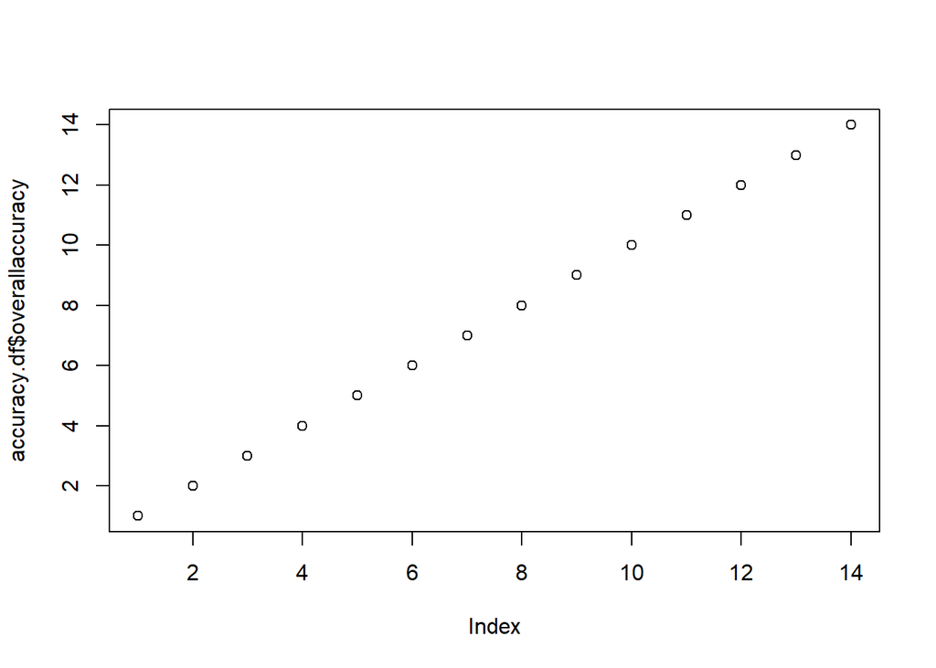

```r
plot(accuracy.df$k,accuracy.df$overallaccuracy)
```

```r
customer.knn3 <- knn(train=train.knn.predictors,
                     test=customer.norm.df,
                     cl=train.knn.success,
                     k=3, prob=TRUE)
head(customer.knn3)
```

```
[1] No
Levels: No
```

**Further examination of k = 3**

**A confusion matrix of the validation data for k=3 is shown below**

```r
knn.k3 <- knn(train = train.knn.predictors,
              test=valid.knn.predictors,
              cl=train.knn.success,
              k=3, prob=TRUE)
confusionMatrix(knn.k3,valid.knn.success,)
```

```
Confusion Matrix and Statistics

          Reference
Prediction   No  Yes
       No  1792   73
       Yes    3  132

               Accuracy : 0.962
                 95% CI : (0.9527, 0.9699)
    No Information Rate : 0.8975
    P-Value [Acc > NIR] : < 2.2e-16

                  Kappa : 0.7567

 Mcnemar's Test P-Value : 2.476e-15

            Sensitivity : 0.9983
            Specificity : 0.6439
         Pos Pred Value : 0.9609
         Neg Pred Value : 0.9778
             Prevalence : 0.8975
         Detection Rate : 0.8960
   Detection Prevalence : 0.9325
      Balanced Accuracy : 0.8211

       'Positive' Class : No
```

**Repartitioning for a test set**

```r
set.seed(500)
Train_Index <- sample(row.names(m_BankInfo), .5*dim(m_BankInfo)[1])
#create train index
Val_Index <- sample(setdiff(row.names(m_BankInfo),Train_Index),.3*dim(m_BankInfo)[1])
#create validation index
Test_Index =setdiff(row.names(m_BankInfo),union(Train_Index,Val_Index))
#create test index
#load the data
Train_Data <- m_BankInfo[Train_Index,]
Validation_Data <- m_BankInfo[Val_Index,]
Test_Data <- m_BankInfo [Test_Index,]
#normalize the quantitative data
norm.values3 <- preProcess(m_BankInfo[,columnsare], method=c("center", "scale"))
train.norm.df3 = Train_Data
val.norm.df3 = Validation_Data
test.norm.df3 = Test_Data
train.norm.df3[, columnsare] <- predict(norm.values3, Train_Data[, columnsare])
val.norm.df3[, columnsare] <- predict(norm.values3, Validation_Data[, columnsare])
test.norm.df3[, columnsare] <- predict(norm.values3, Test_Data[, columnsare])
#run knn for all 3
knn.train <- knn(train=train.norm.df3[,-14],
                 test=train.norm.df3[,-14],
                 cl=train.norm.df3[,14],
                 k=3, prob=TRUE)
knn.val<- knn(train=train.norm.df3[,-14],
              test=val.norm.df3[,-14],
              cl=train.norm.df3[,14],
              k=3, prob=TRUE)
knn.test<- knn(train=train.norm.df3[,-14],
               test=test.norm.df3[,-14],
               cl=train.norm.df3[,14],
               k=3, prob=TRUE)
#display the confusion matrices
confusionMatrix(knn.train,train.norm.df3[,14], positive="Yes")
```

```
Confusion Matrix and Statistics

          Reference
Prediction   No  Yes
       No  2274   50
       Yes    2  174

               Accuracy : 0.9792
                 95% CI : (0.9728, 0.9844)
    No Information Rate : 0.9104
    P-Value [Acc > NIR] : < 2.2e-16

                  Kappa : 0.8589

 Mcnemar's Test P-Value : 7.138e-11

            Sensitivity : 0.7768
            Specificity : 0.9991
         Pos Pred Value : 0.9886
         Neg Pred Value : 0.9785
             Prevalence : 0.0896
         Detection Rate : 0.0696
   Detection Prevalence : 0.0704
      Balanced Accuracy : 0.8880

       'Positive' Class : Yes
```

```r
confusionMatrix(knn.val,val.norm.df3[,14], positive="Yes")
```

```
Confusion Matrix and Statistics

          Reference
Prediction   No  Yes
       No  1335   65
       Yes    5   95

               Accuracy : 0.9533
                 95% CI : (0.9414, 0.9634)
    No Information Rate : 0.8933
    P-Value [Acc > NIR] : < 2.2e-16

                  Kappa : 0.7067

 Mcnemar's Test P-Value : 1.766e-12

            Sensitivity : 0.59375
            Specificity : 0.99627
         Pos Pred Value : 0.95000
         Neg Pred Value : 0.95357
             Prevalence : 0.10667
         Detection Rate : 0.06333
   Detection Prevalence : 0.06667
      Balanced Accuracy : 0.79501

       'Positive' Class : Yes
```

```r
confusionMatrix(knn.test,test.norm.df3[,14], positive="Yes")
```

```
Confusion Matrix and Statistics

          Reference
Prediction  No Yes
       No  904  42
       Yes   0  54

               Accuracy : 0.958
                 95% CI : (0.9436, 0.9696)
    No Information Rate : 0.904
    P-Value [Acc > NIR] : 9.200e-11

                  Kappa : 0.6992

 Mcnemar's Test P-Value : 2.509e-10

            Sensitivity : 0.5625
            Specificity : 1.0000
         Pos Pred Value : 1.0000
         Neg Pred Value : 0.9556
             Prevalence : 0.0960
         Detection Rate : 0.0540
   Detection Prevalence : 0.0540
      Balanced Accuracy : 0.7812

       'Positive' Class : Yes
```